# Screening gewasbeschermingsmiddelen

Johan van Tent

**Gemaakt op:** vrijdag 23 oktober 2020

## Samenvatting

In mei 2020 is een screening van gewasbeschermingsmiddelen uitgevoerd. De screening bevestigt het beeld dat verreweg de meeste gewasbeschermingsmiddelen worden aangetroffen in of binnen de invloedssfeer van de glastuinbouwgebieden. In de Krimpenerwaard worden vrijwel geen gewasbeschermingsmiddelen aangetroffen.

## Inleiding

HHSK heeft een meetnet voor gewasbeschermingsmiddelen (GBM)[^1]. Het meten van gewasbeschermingsmiddelen is erg kostbaar. Daarom worden deze stoffen maar op een beperkt aantal locaties gemeten en vooral gemeten waar deze stoffen verwacht kunnen worden. De meeste meetlocaties liggen daarom in het glastuinbouwgebied.

## Onderzoeksvragen

Deze rapportage geeft een antwoord op de volgende vragen:

1. Waar worden gewasbeschermingsmiddelen aangetroffen?
2. Hoeveel verschillende gewasbeschermingsmiddelen worden aangetroffen?
3. Waar worden welke stoffen worden aangetroffen?
4. Waar hebben welke stoffen een concentratie boven de normwaarde?

### Waar worden GBM aangetroffen

Het ligt voor de hand dat er een relatie is tussen het landgebruik en het aantreffen van gewasbeschermingsmiddelen. In onderstaande kaart is te zien welk landgebruik hoort bij ieder meetpunt.

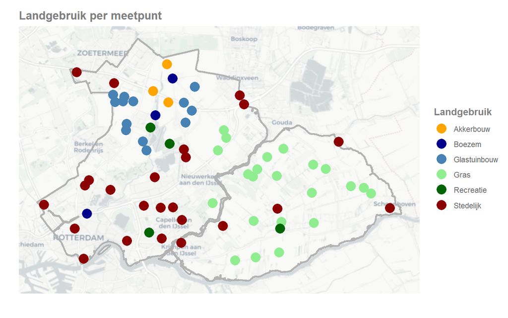

Op de onderstaande kaart is weergegeven op welke locaties gewasbeschermingsmiddelen zijn aangetroffen.

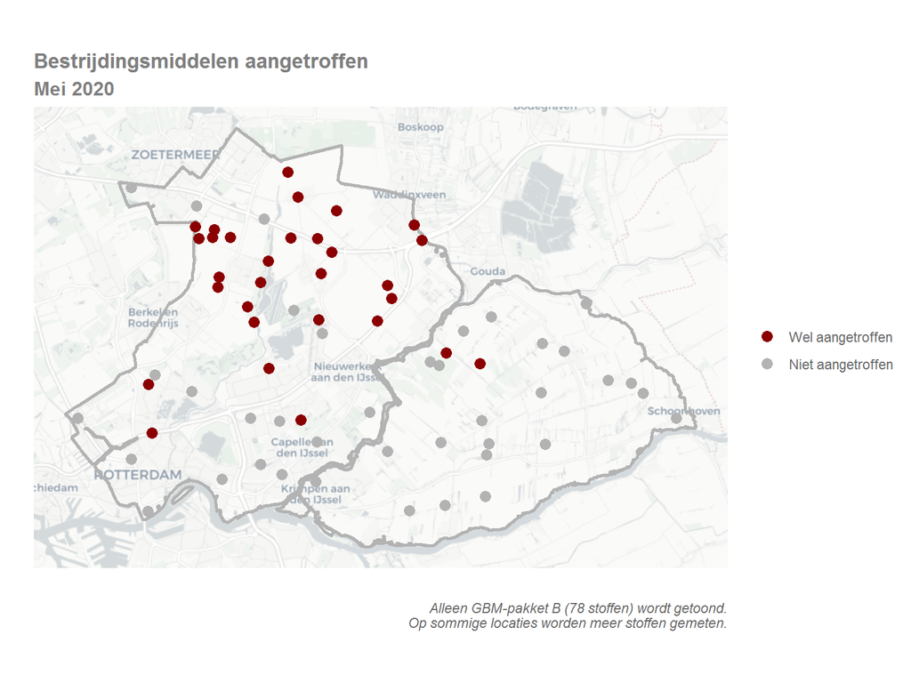

Op de kaart is te zien dat vrijwel alle locaties waar gewasbeschermingsmiddelen worden aangetroffen in Schieland liggen. De locaties met gewasbeschermingsmiddelen in Schieland liggen hoofdzakelijk in of binnen de invloedssfeer van de glastuinbouwgebieden in de Zuidplaspolder en Lansingerland.

### Hoeveel verschillende GBM

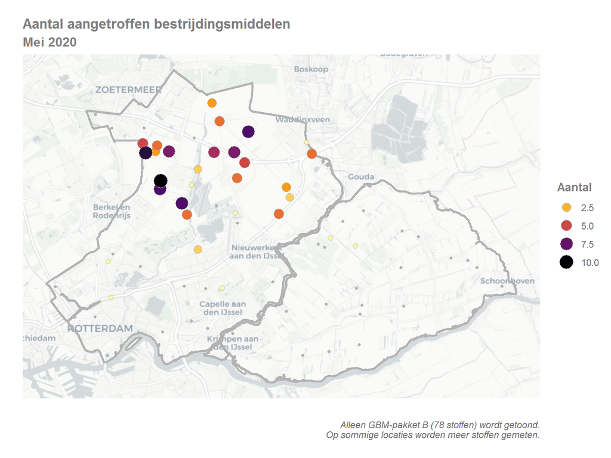

Op de kaart met het aantal aangetroffen gewasbeschermingsmiddelen komt nog duidelijker naar voren dat gewasbeschermingsmiddelen vooral in het glastuinbouwgebied gevonden worden. Hier worden de grootste aantallen gevonden en het aantal neemt af naarmate de afstand tot het glastuinbouwgebied groter wordt.

In de onderstaande figuur is het gemiddeld aantal gevonden gewasbeschermingsmiddelen per landgebruik weergegeven. Ook hier komt weer het beeld naar voren dat gewasbeschermingsmiddelen vooral in het glastuinbouwgebied worden gevonden.

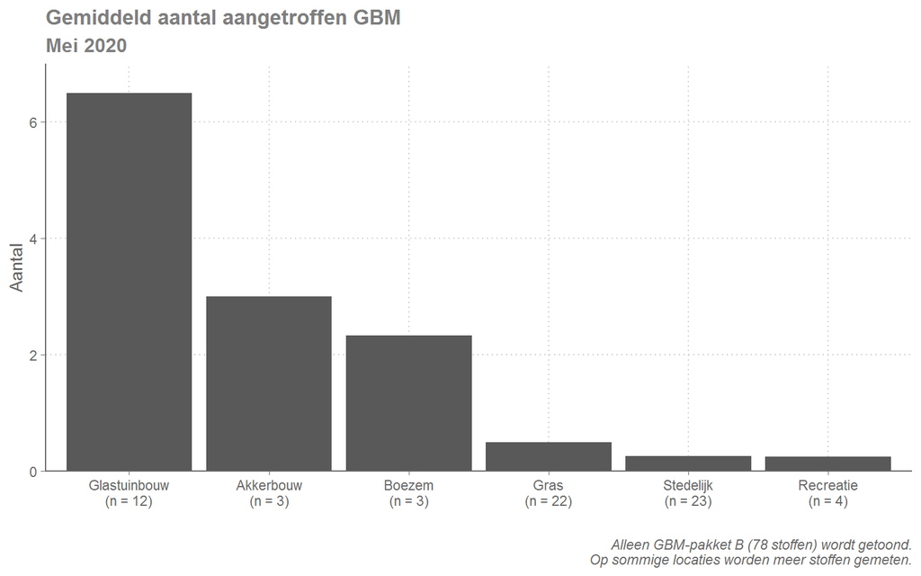

### Welke GBM worden aangetroffen

Op onderstaande kaartjes is weergegeven welke gewasbeschermingsmiddelen op welke locaties zijn aangetroffen. De stoffen carbendazim, fluopyram, flonicamid, boscalid en imidacloprid zijn worden het meest aangetroffen en zijn samen goed voor 75% van alle waarnemingen van gewasbeschermingsmiddelen.

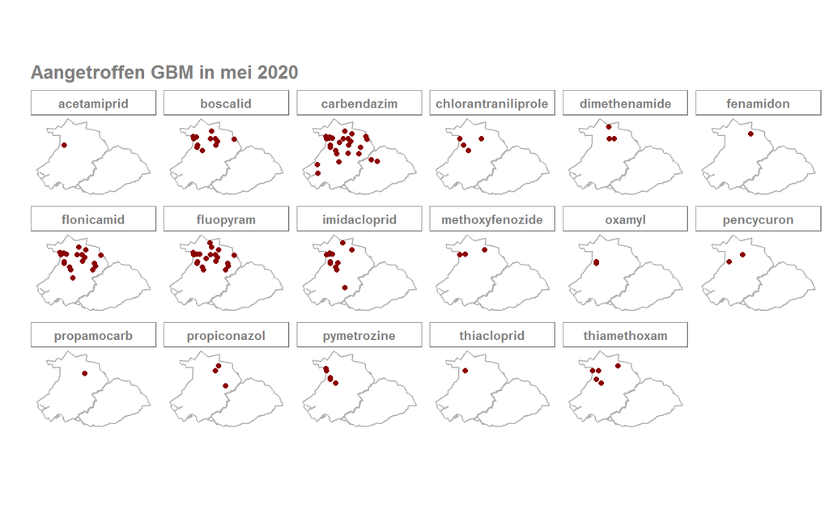

### Welke GBM overschrijden de normwaarde

Het aantal gewasbeschermingsmiddelen van pakket B dat in mei 2020 de norm overschrijdt is beperkt. Vijf stoffen zijn boven de normwaarde gemeten. Het meest opvallend is de stof imidacloprid die op 8 locaties boven de norm is gemeten.

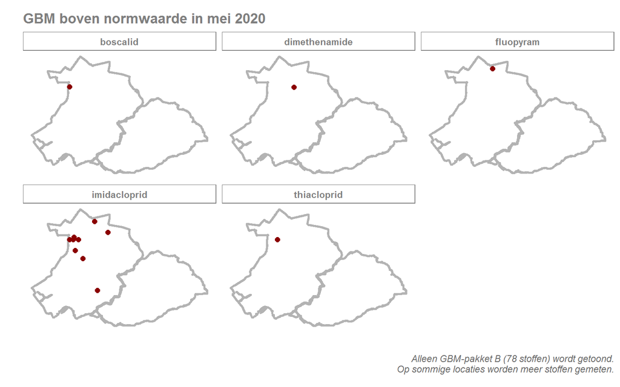

## Conclusie

De screening van gewasbeschermingsmiddelen in 2020 bevestigt het beeld dat er op voorhand al bestond. Verreweg de meeste gewasbeschermingsmiddelen worden aangetroffen in of binnen de invloedssfeer van de glastuinbouwgebieden. In de Krimpenerwaard worden vrijwel geen gewasbeschermingsmiddelen aangetroffen.

[^1]: Gewasbeschermingsmiddelen, ook wel bekend als bestrijdingsmiddelen, zijn giftige stoffen die meestal bedoeld zijn om landbouwgewassen te beschermen tegen schade en ziektes. In deze rapportage worden gewasbeschermingsmiddelen en bestrijdingsmiddelen gebruikt als synoniemen. Soms wordt de afkorting GBM gebruikt.
[^2]: Door het onderzoek te beperken tot GBM-pakket B is er geen compleet beeld van alle gewasbeschermingsmiddelen die in het gebied aanwezig zijn. Het is dus mogelijk dat het beeld voor sommige gewasbeschermingsmiddelen die niet zijn gemeten afwijken van het beeld in deze rapportage.

[figure not shown]